# wrangle_report

## Reporting: wragle_report

- Create a **300-600 word written report** called "wrangle_report.pdf" or "wrangle_report.html" that briefly describes your wrangling efforts. This is to be framed as an internal document.

## Gather

The gathering process had just an hiccup; the inability to get access to Twitter API. Thus denying me of practicing the process of gathering data via APIs. Nevertheless, the thoughtfulness of Udacity to provide the `tweet-json.txt` file made completing this project possible. The data were loadeding in dataframes as below:

- `df1`: WeRateDogs Twitter archive data (twitter_archive_enhanced.csv)
- `df2`: tweet image prediction (image_predictions.tsv)
- `df3`: additional data via the Twitter API (tweet_json.txt)

## Assess

While assessing the data, most of the issues were discovered in `df1` dataframe. This could be easily guessed by mere looking at the attachments below.

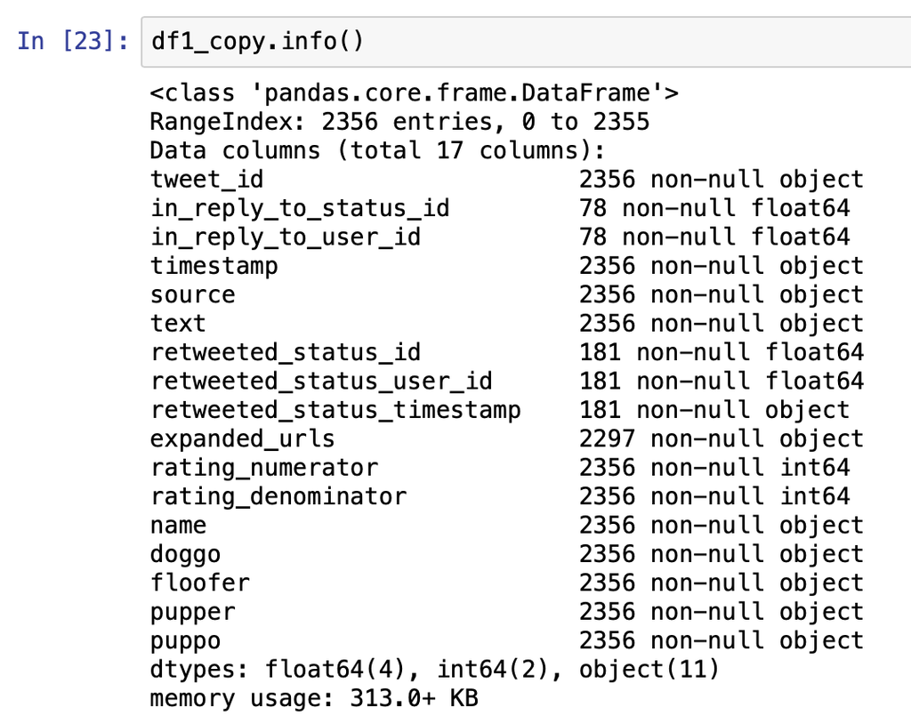

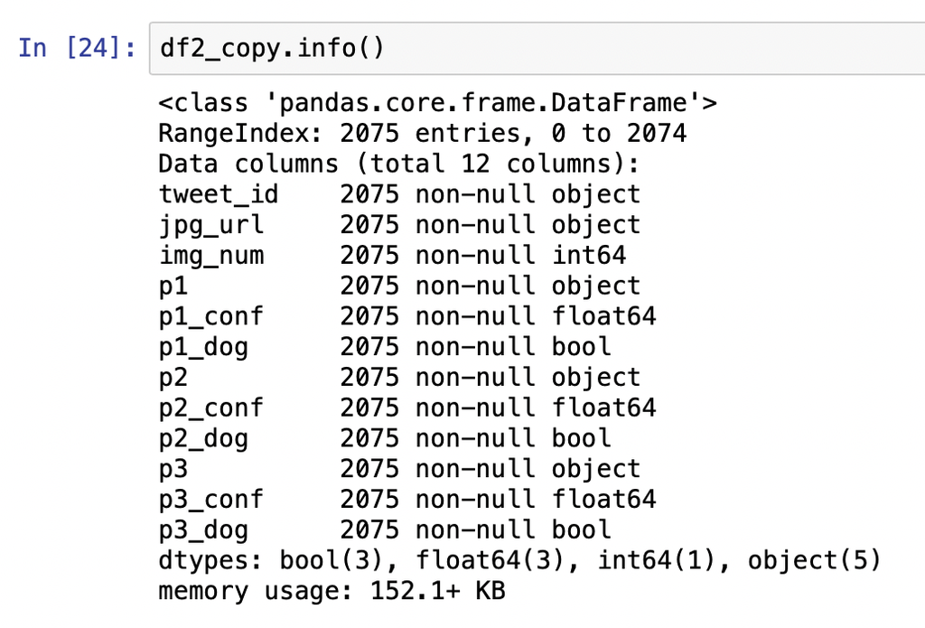

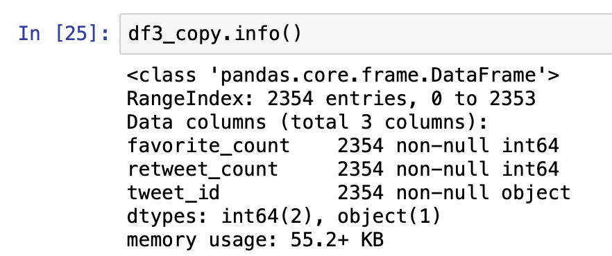

It should be noted that some of this issues were re-defined during the cleaning process to cover for cases where the issues are even or general. Below are the issues uncovered:

#### Quality issues

*df1*

1. Missing values in columns: `in_reply_to_status_id, in_reply_to_user_id, retweeted_status_id, retweeted_status_user_id, retweeted_status_timestamp` (via Visual assessment)
2. Incorrect rating; for instance `Bella (tweet_id = 883482846933004288)` has 5 rating instead of 13.5 (via Visual assessment)
3. Wrong datatype: IDs should be string objects:: `tweet_id` should be str (also in `df2` and `df3` dataframes)
4. Wrong datatype:: `timestep` should be datetime object
5. Wrong datatype:: `rating` should be float not int
6. Remove retweet data
7. Records with incorrect rating_denominators (!= 10)
8. Missing `expanded_urls`
9. Remove reply data

#### Tidiness issues

*df2*

1. Drop information which are unrelated to dogs

*df1*

1. Data Type is not treated a feature; the pupper, doggo, floofer, puppo should be collapsed into a column.

## Clean

The list of the quality and tidiness issues above are in the order at which they were discovered during assessment stage. This order does not in anyway reflect how the cleaning was done. The cleaning process took another a more logic order in the sense that the issues of gnarly consequences were first fixed.

##### Issue #1: Wrong datatype: IDs should be string objects:: tweet_id should be str (also in df2 and df3 dataframes)

The cleaning process started with convert the tweet_id to strings using `.astype`. This is quite approprite since the feature is just for recognition and unique. Thus, should naturally have the same data type as a name.

#### Issue #2: Wrong datatype:: timestamp should be datetime object

Having calender information as string annihilates the analysis potentials of such data. Converting to datetime object removes this limitation.

#### Issue #3: Remove reply data

As we are uninterested in replies, there is a need to remove reply observations. The reply-related colums (in_reply_to_status_id, in_reply_to_user_id) are of great benefit here. The reply observation were found to be the observations with non-null values in the reply-related colums. I used `.isna()` to mask out the reply observations. And tested with `.notna()` to ensure the data is free of reply observations.

#### Issue #4: Remove retweet data

Also, retweet observations are out of interest with regards to the goal of this project. A sequence of activities similar to that used to remove reply data was employed. Either of the retweet-related columns (retweeted_status_id , retweeted_status_user_id, retweeted_status_timestamp) were used for this case.

#### Issue #5: Missing data in columns: `in_reply_to_status_id` , `in_reply_to_user_id`, `retweeted_status_id`, `retweeted_status_user_id` and `retweeted_status_timestamp`

Having clean the data of retweet and reply data, the reply-related and retweet-related columns are not empty and of no use. Proceeding to drop this column is a plausible step since the columns are not of no use. Thus, I used `.drop` to delete the empty columns `in_reply_to_status_id` , `in_reply_to_user_id`, `retweeted_status_id`, `retweeted_status_user_id` and `retweeted_status_timestamp`.

#### Issue #6: Incorrect rating numerator; for instance Bella (tweet_id = 883482846933004288) has 5 rating instead of 13.5:

This singular case of incorrect rating makes me question if there are more incorrect ratings in the dataframe. For this case, I extracted ratings for all observations using `text.str.extract(r'(\d+\.?\d*/\d+)')`. The regex here captures decimal ratings, this is essential because some WeRateDog rating numerators are decimals.

#### Issue #7: Records with incorrect rating_denominators (!= 10):

I was quick to use query to get observations with rating denominators not equal to 10, then inspected the tweet to confirm these were incorrect. After inspection, I discovered that most of the ratings were ratings for multiple dogs, and this is indicated by the rating denominators being multiples of 10. That is, a rating for 5 dogs has denominator 50. Thus, the incorrect rating denominators are those observations with rating not being multiples of 10. In other words, it is therefore correct and consistent to have a rating denominator in the multiple of 10. What is therefore incorrect is the rating denominators such as 7, 11 etc. I found just 4 cases of incorrect rating denominator of which each is unique, I treated the cases individually by inserting the correct rating.

#### Issue #8: Wrong datatype:: ratings (denominator and numerator) should be float not int:

The original data came with ratings as intergers, however are the cleaning step to extract the ratings from the texts, the ratings were returned as string. Strings are also inappropriate for these ratings, it hinders statistical calculations such as computing the mean rating. Since we have earlier uncovered that some ratings were decimals, then it is more appropriate to have ratings stored as floats. I used `.astype(float)` on the `rating_numerator` and `rating_denominator` columns.

#### Issue #9: Missing `expanded_urls`

I observed that the expanded urls are related to the tweet ids in that the urls consist of a particular strings and tweet id. Therefore, I used this finding to fix the expanded url where missing.

#### Issue #10: Drop information which are unrelated to dogs in `df2` dataframe

Since the `df1` dataframe contains dog rating tweet. One can take advantage of this by `pd.merge` the dataframe `df2` to it, knowing the non-dog observations would be dropped.

#### Issue #11: Data Type is not treated a feature; the pupper, doggo, floofer, puppo should be collapsed into a column.

The columns; pupper, doggo, puppo and puppo, all represent dog type. However, treating them as separate columns does harm analysis, because a column is to represent a feature. In this case, it is not so; 4 columns represent a feature. It is quite plausible to merge these columns. Another issue arose, which is the problem that the type of some dogs were unknown. To tackle this, I created a dog type tag `unknown` to indicate that the dog type is unknown.

## Merge additional information (number of retweets and likes) from df3

At this point, only two dataframes were relevant (`df1` and `df3`). I then decided to merger these dataframe, especially because the `df3` contained information that are not in `df1`; thus unrequired.

Finally, we have a singlar dataframe of high quality and well tidied up. Eventhough, there are missing information in the `jpg_url` and `img_num` columns. These information are just unavailable from the any sources provided.

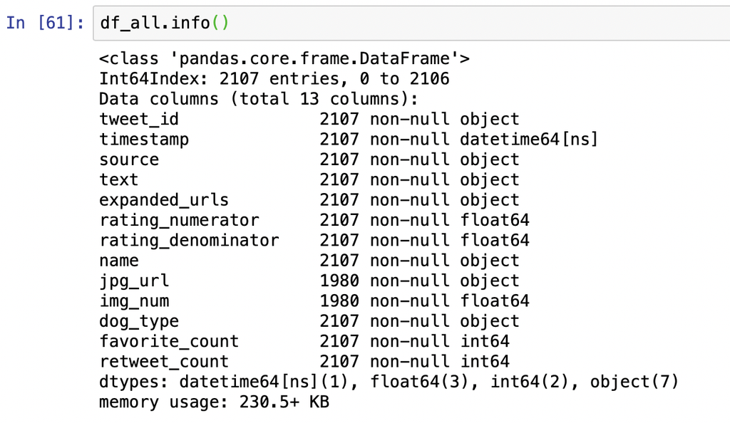